# BIA-658 Lab 3 Exercises

Yuhui Ren

**Note**:

- Submit it as a HTML file (Knit to HTML) as HW3.
- Make sure you that the `Lab-3-Data/` folder is in the same directory of the Rmd file.

```r
library(igraph)
library(tidyverse)
```

Q1. The books about US politics dataset (Valdis Krebs) consists of co-purchasing network of books about US politics sold by Amazon.com. Nodes are the books. Edges represent frequent co-purchasing of books by the same buyers, as indicated by the “customers who bought this book also bought these other books” feature on Amazon.

Nodes have been given values “l”, “n”, or “c” to indicate whether they are “liberal”, “neutral”, or “conservative”.

-use polbooks.gml in the polbooks folder -load the data as a graph object in igraph -find the node values  
-find the size, density and clustering of the network -plot the network with node colors representing node values -what can you tell based on the calculated network structural properties and the plot?(Answer the last question in a sentence starting with # to comment it off)

```r
# Write your code here

bookg <- read.graph(file = "C:/Users/zhou/Desktop/BIA 658/Week 9 Lab 3/Lab3-Data/polbooks/polbooks.gml", format = "gml")
node_values <- V(bookg)$value   # node values
vcount(bookg)   # number of nodes, size
```

```
## [1] 105
```

```r
ecount(bookg)   # number of edges
```

```
## [1] 441
```

```r
graph.density(bookg)   # density
```

```
## [1] 0.08076923
```

```r
transitivity(bookg)    # clustering
```

```
## [1] 0.3484032
```

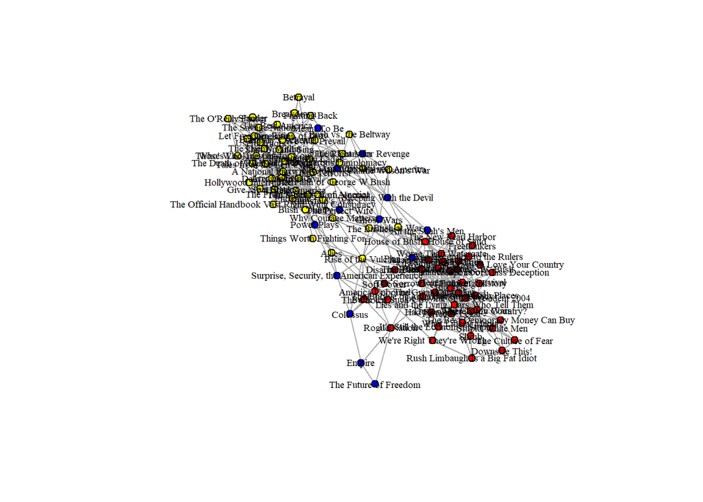

```r
colors <- c("yellow", "red","blue")[as.numeric(as.factor(V(bookg)$value))]
plot(bookg,layout=layout.fruchterman.reingold,vertex.size=5,vertex.color=colors,
     vertex.label.cex=0.6,vertex.label.color="black",vertex.label.font=0.5)
```

```r
# The figure seems like that there are 3 clusters, the left upper part, middle part and the right lower part, transitivity is about 0.35 means the network has a moderate interconnection.
```

Q2. Use the edge betweenness clustering algorithm to detect communities in the network. - How many communities were detected? - What are the sizes of each community? - What’s the modularity score? - Plot the communities in the network with node colors representing their community membership

```r
# Write your code here

book_bc <- edge.betweenness.community(bookg)
length(book_bc)    # 5 communities
```

```
## [1] 5
```

```r
membership(book_bc)
```

```
##   [1] 1 1 1 2 1 1 1 1 2 2 2 2 2 2 2 2 2 2 2 2 2 2 2 2 2 2 2 2 3 1 3 3 2 2 2 2 2
##  [38] 2 2 2 2 2 2 2 2 2 2 2 2 2 2 4 4 2 2 2 2 2 4 3 3 3 3 3 4 4 3 5 4 4 3 3 3 3
##  [75] 3 3 3 3 3 3 3 3 3 3 3 3 3 3 3 3 3 3 3 3 3 3 3 3 3 3 3 3 3 5 5
```

```r
sizes(book_bc)
```

```
## Community sizes
##  1  2  3  4  5
##  8 45 42  7  3
```

```r
modularity(book_bc)
```

```
## [1] 0.5168011
```

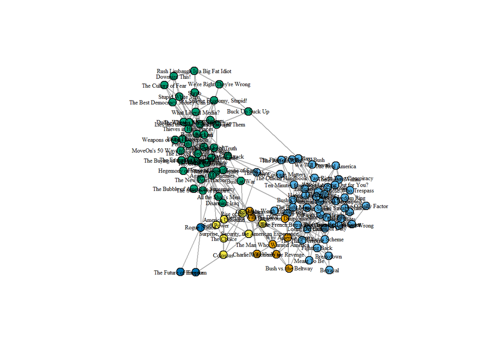

```r
plot(bookg,layout=layout.fruchterman.reingold,vertex.color=membership(book_bc),vertex.size=8,
     vertex.label.cex=0.5,vertex.label.color="black")
```

Q3. Use the Label Propagation algorithm to detect communities in the network. - How many communities were detected? - What are the sizes of each community? - What’s the modularity score? - Plot the communities in the network with node colors representing their community membership

```r
# Write your code here

book_lpc <- label.propagation.community(bookg)
length(book_lpc)
```

```
## [1] 2
```